# Programming basics_20190916_717_oh

# 2. Programming basics

R하는 이유: greatly facilitates data analysis R로 코딩하믄 1.exploratory data analysis 2.build data analysis pipelines 3.prepare data visualization to communicate results 하.지.만. R을 데이타 분석으로만 쓰면 섭섭데스.. 나름 프로그래밍언어인데.. 이걸로 complex pacakages 만들고 하면 나름 짭짤할수도(?)있다고 ㅋㅋ

비록 완전 빠삭한 전문 프로그래밍을 이책서 소개는 안하지만.. key concept인 1. conditional expressions, 2. for-loops, 3. functions. 정도들은 다루어 보죠. 나름 data analysis중에 쓰이긴 하거등요.

또한 뉴비들을 위한 책이라.. 널리 쓰이는 **function**들인 `split`, `cut`, `do.call`,`Reduce`은 못다루고요. 널리쓰이는 **package**인 __data.table__도…ㅠㅠ 아쉽쓰 기타 뭐시기 잘쓰이는 것들도 전부 다루긴 힘들 거 같고요…

## 2.4 For-loops

$1+2+\dots+n$의 공식이 $n(n+1)/2$이거 인건 알죠?. 그래도 맞는걸 확인을 해보면.. `sum`을 써서 $S_n$을 계산해 봅시다.:

```r
compute_s_n <- function(n){
  x <- 1:n
  sum(x)
}
```

Perhaps the simplest example of a for-loop is this useless piece of code:

```r
for(i in 1:5){
  print(i)
}
```

```
## [1] 1
## [1] 2
## [1] 3
## [1] 4
## [1] 5
```

Here is the for-loop we would write for our $S_n$ example:

```r
m <- 25
s_n <- vector(length = m) # create an empty vector
for(n in 1:m){
  s_n[n] <- compute_s_n(n)
}
s_n
```

```
##  [1]   1   3   6  10  15  21  28  36  45  55  66  78  91 105 120 136 153
## [18] 171 190 210 231 253 276 300 325
```

In each iteration $n=1$, $n=2$, etc…, we compute $S_n$ and store it in the $n$th entry of `s_n`.

Now we can create a plot to search for a pattern:

```r
n <- 1:m
plot(n, s_n)
```

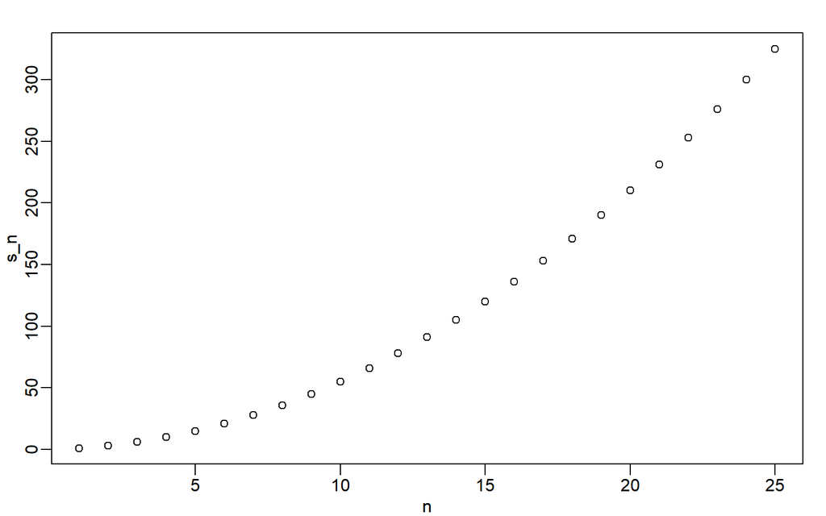

```r
rafalib::mypar()
n <- 1:m
plot(n, s_n)
```

If you noticed that it appears to be a quadratic, you are on the right track because the formula is $n(n+1)/2$. which we can confirm with a table:

```r
head(data.frame(s_n = s_n, formula = n*(n+1)/2))
```

```
##   s_n formula
## 1   1       1
## 2   3       3
## 3   6       6
## 4  10      10
## 5  15      15
## 6  21      21
```

We can also overlay the two results by using the function `lines` to draw a line over the previously plotted points:

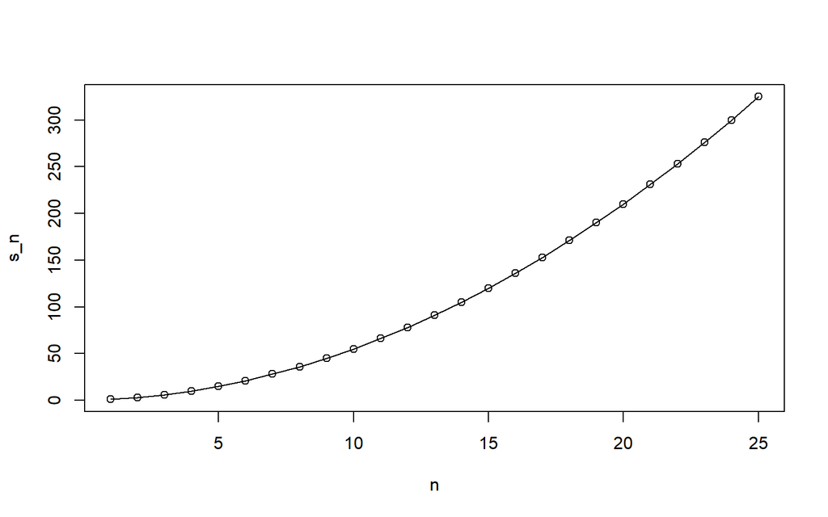

```r
plot(n, s_n)
lines(n, n*(n+1)/2)
```

## 2.5 Vectorization and functionals

Although for-loops are an important concept to understand, in R we rarely use them. As you learn more R, you will realize that *vectorization* is preferred over for-loops since it results in shorter and clearer code. We already saw examples in the Vector Arithmetic section. A *vectorized* function is a function that will apply the same operation on each of the vectors.

```r
x <- 1:10
sqrt(x)
```

```
##  [1] 1.000000 1.414214 1.732051 2.000000 2.236068 2.449490 2.645751
##  [8] 2.828427 3.000000 3.162278
```

```r
y <- 1:10
x*y
```

```
##  [1]   1   4   9  16  25  36  49  64  81 100
```

To make this calculation, there is no need for for-loops. However, not all functions work this way. For instance, the function we just wrote, `compute_s_n`, does not work element-wise since it is expecting a scalar. This piece of code does not run the function on each entry of `n`:

```r
n <- 1:25
compute_s_n(n)
```

*Functionals* are functions that help us apply the same function to each entry in a vector, matrix, data frame, or list. Here we cover the functional that operates on numeric, logical, and character vectors: `sapply`.

The function `sapply` permits us to perform element-wise operations on any function. Here is how it works:

```r
x <- 1:10
sapply(x, sqrt)
```

```
##  [1] 1.000000 1.414214 1.732051 2.000000 2.236068 2.449490 2.645751
##  [8] 2.828427 3.000000 3.162278
```

Each element of `x` is passed on to the function `sqrt` and the result is returned. These results are concatenated. In this case, the result is a vector of the same length as the original `x`. This implies that the for-loop above can be written as follows:

```r
n <- 1:25
s_n <- sapply(n, compute_s_n)
```

Other functionals are `apply`, `lapply`, `tapply`, `mapply`, `vapply`, and `replicate`. We mostly use `sapply`, `apply`, and `replicate` in this book, but we recommend familiarizing yourselves with the others as they can be very useful.

## Exercises

1. What will this conditional expression return?

```r
x <- c(1,2,-3,4)

if(all(x>0)){
  print("All Postives")
} else{
  print("Not all positives")
}
```

**my answer: : “NOT all positives” <- -3땜시.**

2. Which of the following expressions is always `FALSE` when at least one entry of a logical vector `x` is TRUE?

1. `all(x)`
2. `any(x)`
3. `any(!x)`
4. `all(!x)`

```r
x <- c(TRUE, FALSE, FALSE)
x
```

```
## [1]  TRUE FALSE FALSE
```

```r
!x
```

```
## [1] FALSE  TRUE  TRUE
```

```r
all(x)
```

```
## [1] FALSE
```

```r
any(x)
```

```
## [1] TRUE
```

```r
any(!x)
```

```
## [1] TRUE
```

```r
all(!x)
```

```
## [1] FALSE
```

3. The function `nchar` tells you how many characters long a character vector is. Write a line of code that assigns to the object `new_names` the state abbreviation when the state name is longer than 8 characters.

```r
#use nchar to load
nchar(murders$state)
# 8이하 놈들만 sort
new_names <- nchar(murders$state) < 8
#약자들만 불러오기
murders$abb[new_names]
```

4. Create a function `sum_n` that for any given value, say $n$, computes the sum of the integers from 1 to n (inclusive). Use the function to determine the sum of integers from 1 to 5,000.

```r
#1. 그냥 수학 공식 쓰기
sum_n <- function(n){
  (n*(n+1)/2)
}
sum_n(n=5000)
```

```
## [1] 12502500
```

```r
#2. 코드로만
sum_n <- function(n){
  sum(1:n)
}
sum_n(n=5000)
```

```
## [1] 12502500
```

5. Create a function `altman_plot` that takes two arguments, `x` and `y`, and plots the difference against the sum.

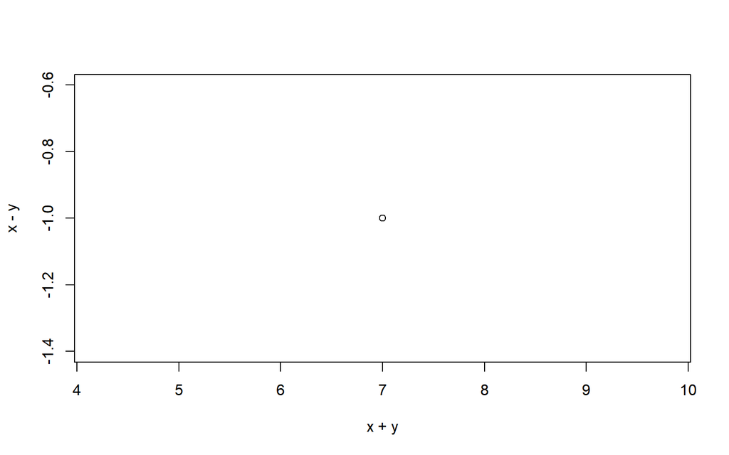

```r
#x,y 합에 따른 x,y의 차이 plot 함수 만들기
altman_plot <- function(x,y){
  plot(x + y, x - y)
}
altman_plot(3, 4)
```

6. After running the code below, what is the value of `x`?

```r
x <- 3
my_func <- function(y){
  x <- 5
  y+5
}
x
```

**my answer: 3 <- 맨위에 3으로 assign하고 y에 관한 함수라 variable안변함**

7. Write a function `compute_s_n` that for any given $n$ computes the sum $S_n = 1^2 + 2^2 + 3^2 + \dots n^2$. Report the value of the sum when $n=10$.

```r
#1. 그냥 공식 쓰기
compute_s_n <- function(n){
  print(n*(n+1)*(2*n+1)/6)
}
compute_s_n(10)
```

```
## [1] 385
```

```r
# 코드로만 만들기 실패한것
compute_s_n <- function(n){
  print((sum(1:n))^2)
}
compute_s_n(10)
```

```
## [1] 3025
```

```r
# 코드로만 만들기 성공한것
compute_s_n <- function(n){
  n <- 1:n
  sum(n^2)
}
compute_s_n(10)
```

```
## [1] 385
```

8. Define an empty numerical vector `s_n` of size 25 using `s_n <- vector("numeric", 25)` and store in the results of $S_1, S_2, \dots S_{25}$ using a for-loop.

```r
s_n <- vector("numeric", 25)
s_n
```

```
##  [1] 0 0 0 0 0 0 0 0 0 0 0 0 0 0 0 0 0 0 0 0 0 0 0 0 0
```

```r
#그냥 단순 1부터 25까지 저장
for (n in 1:25) {
  s_n[n] <- n
}
print(s_n)
```

```
##  [1]  1  2  3  4  5  6  7  8  9 10 11 12 13 14 15 16 17 18 19 20 21 22 23
## [24] 24 25
```

```r
#1 부터 n번째 숫자까지 더한것
for (n in 1:25) {
  s_n[n] <- sum_n(n)
}
print(s_n)
```

```
##  [1]   1   3   6  10  15  21  28  36  45  55  66  78  91 105 120 136 153
## [18] 171 190 210 231 253 276 300 325
```

9. Repeat exercise 8, but this time use `sapply`.

```r
sapply(1:25, sum_n)
```

```
##  [1]   1   3   6  10  15  21  28  36  45  55  66  78  91 105 120 136 153
## [18] 171 190 210 231 253 276 300 325
```

10. Repeat exercise 8, but this time use `map_dbl`.

```r
#map_dbl(1:25, sum_n)
```

11. Plot $S_n$ versus $n$. Use points defined by $n=1,\dots,25$.

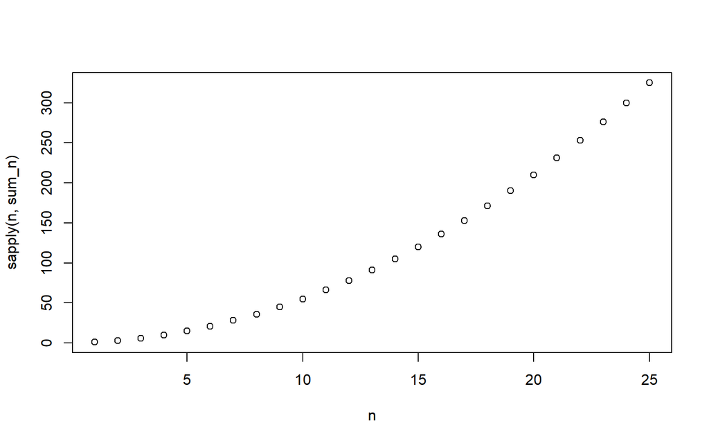

```r
n <- c(1:25)
#아래 출력된 n은 1부터 25까지 한 덩어리임
#아래꺼는 Error in xy.coords(x, y, xlabel, ylabel, log) : 'x' and 'y' lengths differ 나옴 -->> sum_n()의 함수 값은 1개임!
#plot(n,sum_n(n))
plot(n, sapply(n, sum_n))
```

12. Confirm that the formula for this sum is $S_n= n(n+1)(2n+1)/6$.

```r
#임의의 수인 n=25로 확인하기
#각 제곱의 합 함수
compute_s_n(25)
```

```
## [1] 5525
```

```r
#확인 절차
n = 25
print(n*(n+1)*(2*n+1)/6)
```

```
## [1] 5525
```